# Regularization in Machine Learning

For DATA50XX by ctong

## Bias-Variance Trade-off

### Understanding the Bias-Variance Tradeoff

When you build a machine learning model, your goal is to predict accurately on new, unseen data. This requires balancing two sources of error - this is known as the bias-variance tradeoff:

| Concept | Description | Analogy |
| --- | --- | --- |
| Bias | Error from simplifying too much (underfitting) | A student who always guesses “C” on multiple choice tests |
| Variance | Error from being too sensitive to training data (overfitting) | A student who memorizes answers to a practice test but fails the real exam |
| Irreducible error | Noise in the data that is out of our control | Random variation, measurement errors, etc. |

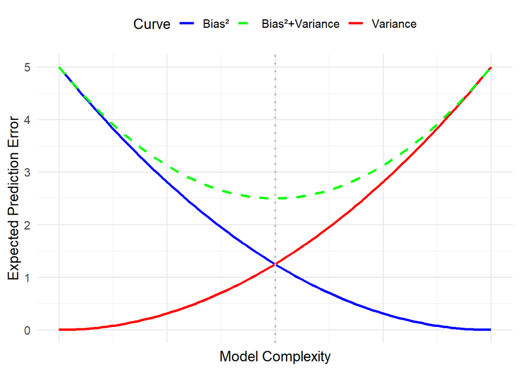

🔵 **Bias²** decreases as model complexity increases (simpler models miss important patterns — underfitting).

🔴 **Variance** increases with model complexity (complex models overreact to noise — overfitting).

🟢 **Total Error** = Bias² + Variance (+ Irreducible Error). It is minimized at the **“sweet spot”**.

### The best model minimizes total error by balancing bias and variance.

## Regularization

### The Problem: Choosing Between Too Simple and Too Complex

Imagine you’re trying to draw a line through a cloud of data points to make predictions.

- If your model is **too simple** (like a straight line when the pattern is curvy), it **misses important patterns** — this is **high bias**.
- If your model is **too complex** (it bends to fit every single point perfectly), it starts to **memorize the noise** — this is **high variance**.

The goal is to find a **happy medium** — a model that’s flexible enough to learn real patterns, but not so flexible that it learns randomness.

### What Regularization Does

Regularization is a technique that **gently pushes your model away from overfitting** by adding a “penalty” for being too complex.

Think of it like setting **boundaries** for your model — “yes, you can learn, but don’t get carried away.”

### How It Works

- Regression models have **coefficients** that reflect how strongly each feature (predictor) influences the prediction. These coefficients are typically computed by minimizing some loss function. In linear regression, the most commonly used loss function is the mean squared error (MSE).
- Without any restrictions, these coefficients can become **very large**, especially when the model is trying too hard to match every detail in the training data.
- Regularization (also known as Shrinking Methods) restricts the size of the coefficients by adding a penalty that scales with the **size** of the coefficients. It’s like saying “Hey model — you’re allowed to use these features, but **keep their coefficients small** unless you’re really sure they’re useful.”

By **shrinking the size of the coefficients**, regularization:

- Encourages the model to focus on the **strongest, most reliable patterns**
- Ignores or downplays the weak, noisy signals
- Produces **simpler models that generalize better** to new data

### Lasso Regression (L1 Regularization)

Penalizes the sum of the absolute values of coefficients.

$Loss = MSE + \lambda \sum_{i=1}^{n} |w_i|$

- Adds L1 penalty (absolute value of coefficients). Lasso stands for Least Absolute Shrinkage and Selection Operator.
- Can shrink some coefficients to zero, leading to sparsity (model which uses only a small number of predictors while ignoring the rest).
- Performs feature selection by removing irrelevant predictors, simplifying the model and improving interpretability.
- $\lambda$ controls the strength of regularization. Larger values penalizes the coefficients more. $\lambda$ is considered a hyperparameter - a parameter which is not learned from training data, but must be **tuned** using techniques like cross-validation.

*What does L1 mean?*

L1 stands for L1 norm. In algebra, norms are functions which quantify the size of a vector. L1 norm is a member of a family of Lp norms, where p (power) represents the exponent used in the function. L1 norm (aka Manhattan norm) measures distance by summing the absolute values in a vector. It’s like walking in a grid, i.e., Manhattan blocks in New York City.

### Ridge Regression (L2 Regularization)

Penalizes the sum of the squared coefficients.

$Loss = MSE + \lambda \sum_{i=1}^{n} w_i^2$

- Adds L2 penalty (squared coefficients). The L2 norm (aka Euclidean norm) measures the straight-line distance between the coefficients vector from the origin.
- Shrinks coefficients but does not eliminate them.
- Useful when all features contribute to the outcome.
- $\lambda$ controls the strength of regularization. Larger values penalizes the coefficients more.

### Elastic-Net Regression (Combines L1 and L2)

Combines L1 and L2 penalties.

$Loss = MSE + \lambda \left( r \sum_{j=1}^{m} |w_j| + \frac{(1 - r)}{2} \sum_{j=1}^{m} w_j^2 \right)$

- Combines penalties used in Lasso and Ridge regression
- The hyperparameter $r$ determines the relative contribution of L1 and L2 penalties. $r$ = 1 eliminates L2 penalty and produces pure Lasso regression. $r$ = 0 eliminates L1 penalty and produces pure Ridge regression.
- Can work better than using only one of L1 and L2 penalties, but requires tuning of two hyperparameters, $\lambda$ and $r$.

## Demo with Boston Data

The Boston dataset from the MASS package contains housing data for suburbs in Boston, collected by the US Census Bureau in the 1970s. We will apply Lasso and Ridge regression to predict the median value of owner-occupied homes (target variable: *medv*) from neighbourhood characteristics.

### Load and Prepare the Boston Housing Data

```r
library(MASS)
data(Boston)
Boston <- na.omit(Boston) # removes entries with missing values
x <- model.matrix(medv ~ ., Boston)[, -1]  # remove intercept
y <- Boston$medv
```

### 🔧 Fit Lasso Regression (L1)

```r
set.seed(123) # for reproducibility
cv_lasso <- cv.glmnet(x, y, alpha = 1)
summary(cv_lasso$lambda) # lambda values tested
```

```
##     Min.  1st Qu.   Median     Mean  3rd Qu.     Max.
## 0.006321 0.036199 0.207204 1.003001 1.185391 6.777654
```

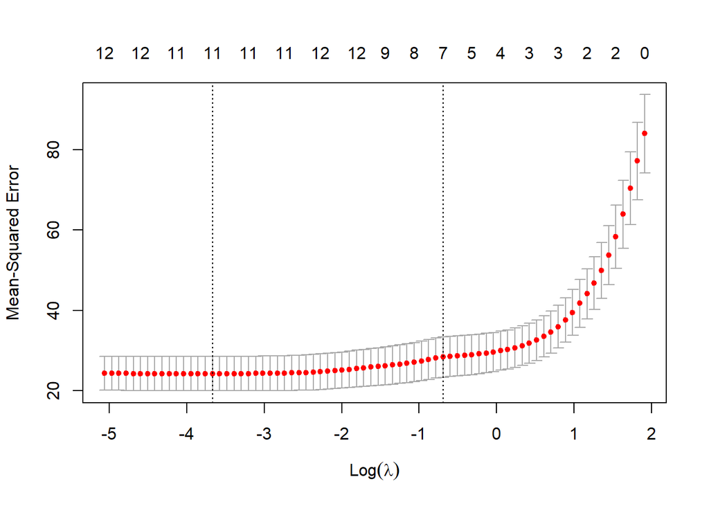

```r
plot(cv_lasso) # numbers on top = number of non-zero coefficients
```

```r
best_lambda_lasso <- cv_lasso$lambda.min # lambda value for min error

lasso_in_rmse <- sqrt(mean((predict(cv_lasso, newx = x, s=best_lambda_lasso) - y)^2))
lasso_out_rmse = sqrt(min(cv_lasso$cvm)) # cvm stands for cross-validated mean error
coef(cv_lasso, s = "lambda.min")
```

```
## 14 x 1 sparse Matrix of class "dgCMatrix"
##                        s1
## (Intercept)  34.594713536
## crim         -0.099226869
## zn            0.041830020
## indus         .
## chas          2.688250324
## nox         -16.401122005
## rm            3.861229964
## age           .
## dis          -1.404571750
## rad           0.256788020
## tax          -0.009997514
## ptratio      -0.931437290
## black         0.009049252
## lstat        -0.522505968
```

### 🔧 Fit Ridge Regression (L2)

```r
set.seed(123) # for reproducibility
cv_ridge <- cv.glmnet(x, y, alpha = 0)
summary(cv_ridge$lambda) # lambda values tested
```

```
##     Min.  1st Qu.   Median     Mean  3rd Qu.     Max.
##    0.678    6.783   67.850  762.860  678.324 6777.654
```

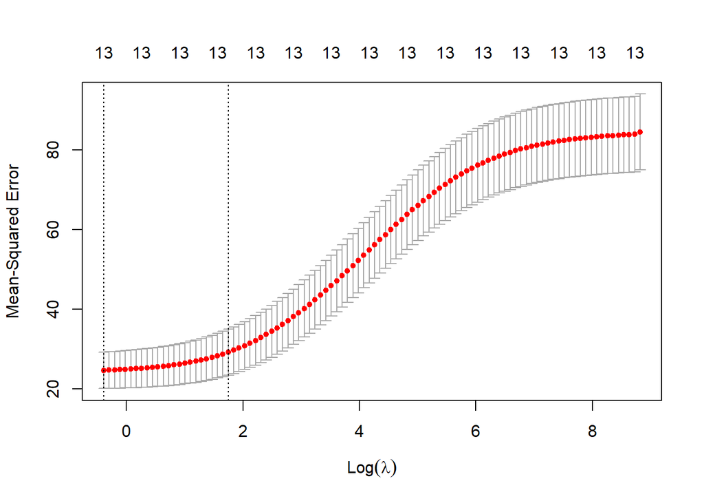

```r
plot(cv_ridge) # numbers on top = number of non-zero coefficients
```

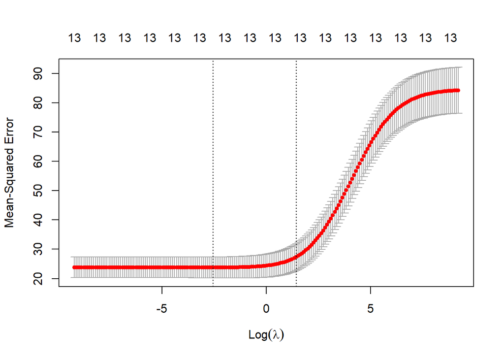

```r
# lambda.min is the smallest lambda value tested -- need to expand range of lambda values tested
lambda_range <- 10^seq(-4, 4, length = 200)
set.seed(123) # for reproducibility
cv_ridge<- cv.glmnet(x, y, nfolds=20,alpha=0, lambda=lambda_range)
plot(cv_ridge) # numbers on top = number of non-zero coefficients
```

```r
best_lambda_ridge=cv_ridge$lambda.min

ridge_in_rmse <- sqrt(mean((predict(cv_ridge, newx=x, s=best_lambda_ridge) - y)^2))
ridge_out_rmse = sqrt(min(cv_ridge$cvm)) # cvm stands for cross-validated mean error
coef(cv_ridge, s = "lambda.min")
```

```
## 14 x 1 sparse Matrix of class "dgCMatrix"
##                        s1
## (Intercept)  3.489085e+01
## crim        -1.038497e-01
## zn           4.376570e-02
## indus        6.740226e-03
## chas         2.740110e+00
## nox         -1.674782e+01
## rm           3.859178e+00
## age         -2.046725e-04
## dis         -1.421740e+00
## rad          2.726274e-01
## tax         -1.075102e-02
## ptratio     -9.363908e-01
## black        9.288883e-03
## lstat       -5.172404e-01
```

### 📈 Visualize Coefficient Paths

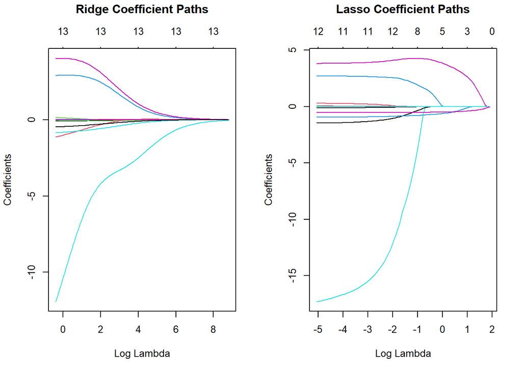

```r
ridge_model <- glmnet(x, y, alpha = 0)
lasso_model <- glmnet(x, y, alpha = 1)

par(mfrow = c(1, 2), cex = 0.8)
plot(ridge_model, xvar = "lambda")
title("Ridge Coefficient Paths", line = 3)
plot(lasso_model, xvar = "lambda")
title("Lasso Coefficient Paths", line = 3)
```

### Compare Models

```r
data.frame(
  Model = c("Ridge", "Lasso"),
  Lambda = c(best_lambda_ridge, best_lambda_lasso),
  InSample_RMSE = c(ridge_in_rmse, lasso_in_rmse),
  OutOfSample_RMSE=c(ridge_out_rmse, lasso_out_rmse)
)
```

```
##   Model     Lambda InSample_RMSE OutOfSample_RMSE
## 1 Ridge 0.07842822      4.681081         4.878858
## 2 Lasso 0.02551743      4.682993         4.927524
```

## Lab with Hitters Data

In this lab, you will apply Ridge and Lasso regression models to the Hitters dataset from the ISLR Package. This dataset contains information about professional baseball players, including performance statistics and salaries.

### Instructions

1. Fit ridge and lasso models using cross-validation to predict player salaries. Include `set.seed(123)` before each model fit to ensure reproducibility.
   - What is the best (optimal) lambda value for each model?
2. Examine the coefficients for each model using their respective best lambda value.
   - How many non-zero coefficients are in each model?
3. Visualize the coefficient paths for each model.
   - Which model aggressively reduces coefficients to zero?
   - What happens to the coefficients as lambda increases?
4. Compare the two models.
   - Which model would you use if you want the most accurate prediction?
   - Which model would you use if you want a simpler, easier-to-explain model?
5. Perform stepwise regression to select features for predicting player salaries.
   - How does the final model from stepwise regression compare to the lasso and ridge models?

## Summary

### Regularization

#### 1. Prevents Overfitting

Overfitting occurs when a model learns the noise in the training data instead of the underlying pattern. Without regularization, models can assign very large coefficients to predictors in an effort to perfectly fit the training data, which causes instability and poor performance on unseen data.

**How regularization helps:**  
Penalizing large coefficients (through Ridge or Lasso) keeps the model simpler and prevents it from reacting too strongly to small fluctuations in the data. This reduces overfitting.

#### 2. Improves Generalization

Generalization refers to the model’s ability to perform well on new, unseen data. Large coefficients can make the model very sensitive to small changes in input values, leading to unstable predictions.

**How regularization helps:**  
By shrinking coefficients, regularization produces more stable predictions, improving the model’s generalization to new data.

#### 3. Handles Multicollinearity

Multicollinearity arises when predictors are highly correlated with one another. This makes it hard to distinguish the effect of each predictor, leading to unstable and inflated coefficient estimates.

**How regularization helps:**

- **Ridge regression:** Distributes the effect among correlated predictors, shrinking their coefficients.
- **Lasso regression:** Performs variable selection by shrinking some coefficients to zero, potentially removing redundant variables.